# 行動経済学の実証分析

Tomohisa OKADA

2023-07-05

# Ready?

## R(Studio)とは？

- Rは、オープンソースで利用可能な統計解析に特化したプログラミング言語
- RStudioは、Rを使うための統合開発環境（なくてもRは使えるが、あるとめちゃ便利！）
- 今は「まったく意味不明」で全然OK！

## Tips!

- Rに関するお役立ちサイトや書籍をまとめる
1. [「卒業論文のためのR入門」 by 森知晴先生](https://tomoecon.github.io/R_for_graduate_thesis/)  
   Rの使い方と心理統計学の基礎が一挙に学べる！
2. [「私たちのR」 by 宋財泫先生 & 矢内勇生先生](https://www.jaysong.net/RBook/datahandling1.html)  
   辞書的に使える！Tidyverseを使ったモダンなRのプログラムが学べる！
3. [「経営工学雑記帖」内のRのページ by 逆瀬川浩孝先生](http://www.f.waseda.jp/sakas/R/index.html)  
   網羅的でスッキリわかりやすい！辞書的に使うのにオススメ
4. [「Rによる統計入門」 by 津田裕之先生](https://htsuda.net/stats/)  
   Rの基礎から簡単な統計分析まで（因子分析もカバー）
5. [「Rで計量政治学入門」 by 土井翔平先生](https://shohei-doi.github.io/quant_polisci/index.html)  
   政治学の研究者以外にも有用！特にデータの読み込みやtidyverseの使い方が詳しい！

## R(Studio)のインストール

- 次のサイトにアクセス( https://posit.co/download/rstudio-desktop/ )
- 「1:Install R」からRをインストール
- 「2:Install RStudio」からRStudioをインストール
- うまくインストールできない場合は、[「私たちのR」](https://www.jaysong.net/RBook/installation.html)に超詳しい解説がある

# Go!!

- とりあえずまずは使ってみよう！

## RStudioを開く

- RStudioのアイコンから起動
- 次のような画面が表示される

[figure not shown]

## コンソールに直接打ち込む

- 左側の大きな枠を見る
- Consoleのタブが選択されていることを確認
- この画面（＝コンソール）を使い、簡単な足し算を実行しよう
- 最下段の`>`のあとに`1+1`と打ち込み**Enter（macはreturn）**を押す
- `[1] 2`と返ってくる
- `2`の部分が`1+1`の計算結果（`[1]`は1行目という意味）

[figure not shown]

## Rスクリプトを使う

- コンソールに書いたコードは、Rstudioを終了すると消える  
  （実際に終了して再起動してみよう）
- だから、**Rスクリプト**と呼ばれる保存可能なファイルにコードを書くことが多い

##### Rスクリプトを作る：

- RStudioの左上の をクリックし、「R Script」を選択
- 左上に新しくできた枠に、空のRスクリプトファイルが表示される  
  （untitled1と表示されたタブが作成したRスクリプト）

##### RStudioの４つのペーン：

- 実際には、この４つの枠（＝ペーン）に分かれた画面で作業することが多い

[figure not shown]

**①左上：**メインの作業場で、Rスクリプトのコードなどを書くところ  
**②右上：**変数やオブジェクトのリストが表示されたり、バージョン管理を行う  
**③左下：**コードの実行結果が表示されるコンソールや、各種コマンドを実行するターミナルなど  
**④右下：**各種ファイルやパッケージの表示、出力した図の表示など

#### Rスクリプトに書く：

- 左上のペーンを見て、untitled1のタブが選択されていることを確認
- 1行目に`1+1`と入力して**ctrl+Enter（macはcommand+return）**を押す  
  （ をクリックしても良い）
- 左下のペーンのコンソールに結果(`[1] 2`)が表示される

##### 保存：

- Rスクリプトは**ctrl+s（macはcommand+s）**で好きな時に保存できる  
  （ をクリックしても良い）
- 初回はファイル名と保存場所も決める （test.Rという名前でデスクトップに保存してみよう）
- 試しに、保存したRスクリプトのタブを閉じてみよう （test.Rのタブの右側の×をクリック）
- 左上の をクリックし、保存したRスクリプトのファイルを選択  
  （つまり、デスクトップにあるtest.Rを選択）
- Rスクリプトが先ほど保存した状態で開く

##### Rスクリプトを使うメリット：

1. コードが保存できる（毎回書き直さなくて良い！）
2. 長く複雑なコードを書いたり、管理するのが楽
3. 他の人に配布できる（分析を再現してもらいやすい）  
   などなど…

## プロジェクト管理

- 研究プロジェクトが進むと、ひとつのRスクリプトだけでは管理しきれなくなる
- **プロジェクト**を使えば、複数のRスクリプトや関連データなどを一つのフォルダにまとめて効率よく管理できる

##### プロジェクトの作成：

- 左上の をクリックし、「New Directry」→「New Project」の順に選択
- 次の画面で①プロジェクト名と、その②作成場所を指定して③「Create Project」

[figure not shown]

- 指定した場所に、指定したプロジェクト名のフォルダができているのを確認しよう  
  (以降、これを**プロジェクトフォルダ**と呼ぶ)
- そのフォルダの中に`プロジェクト名.Rproj`というファイルができているのを確認しよう
- 以下は、macで`Document`フォルダ内に`sugoi_project`というプロジェクトを作った例

[figure not shown]

- 初めはご利益がわかりにくいが、研究プロジェクトごとにプロジェクトを作るクセをつけよう
- そして、次の心得に従い、プロジェクト上で作業をするようにしよう！
1. 毎回`プロジェクト名.Rproj`をダブルクリックしてRstudioを起動
2. 関連するファイルはプロジェクトフォルダにまとめて一元管理

## 演習問題

- 自分の好きな場所に`zemi`という名前のプロジェクトを作る
- 指定した場所に`zemi`というフォルダができているのを確認する
- フォルダの中に`zemi.Rproj`というファイルが出来ているのを確認

**※ 今後は、この`zemi`プロジェクトで作業していることを前提に解説する**

# 基本操作①

- 本章の説明がわからない人は、森知晴先生のすばらしい動画たちを参考にしよう！
1. [オブジェクトの使い方 in R](https://youtu.be/CblsIBlzqX0)
2. [関数の使い方 in R](https://youtu.be/q8MI6P2hoUM)
- データ型やデータ構造については、逆瀬川浩孝先生のホームページを参照

[「経営工学雑記帖」内のRのページ](http://www.f.waseda.jp/sakas/R/index.html)

## 四則演算

**たし算:** `+`を使う

```r
1 + 1
```

```
## [1] 2
```

**ひき算:** `-`を使う

```r
5 - 2
```

```
## [1] 3
```

**かけ算:** `*`を使う

```r
4 * 5
```

```
## [1] 20
```

**わり算:** `/`を使う（分数のイメージ）

```r
8 / 2
```

```
## [1] 4
```

**累乗:** `^`か`**`を使う（例：$4^2$なら次のとおり）

```r
4 ^ 2
```

```
## [1] 16
```

```r
4 ** 2
```

```
## [1] 16
```

- 例えば、9÷2の答えは「4余り1」
- この時、４を整数の商、1を剰余という

**整数の商:** `%/%`

```r
9%/%2
```

```
## [1] 4
```

**剰余（mod）:** `%%`

```r
9%%2
```

```
## [1] 1
```

## 変数（オブジェクト）

- オブジェクトとは、色々なモノを入れる箱のようなもの[^1]
- オブジェクトを変数という人もいる（数学の変数のようなイメージだから）
- 本資料では変数と呼ぶことにする（字数が少ないから）
- 次のコードを見てみよう

```r
x <- 1 # <- は左向矢印のイメージ

# このように#から始まる文章を書いてコメントを残せる
# これをコメントアウトと呼ぶ
# あとで見てわかりやすいような覚え書きなどを残そう
```

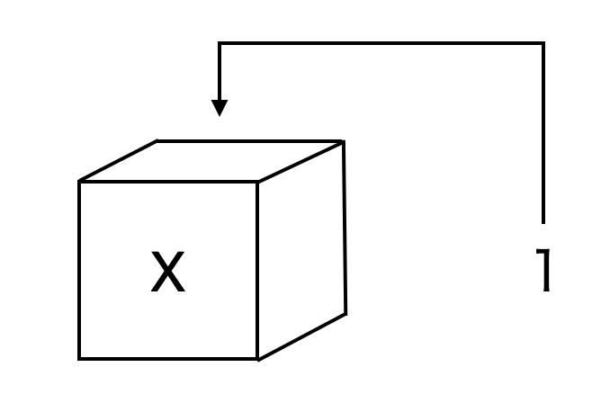

- これはxという箱を作り、その中に数字の1を入れたイメージ  
  （変数xに１を代入したイメージでもOK！）
- 上のコードを実行しても何も表示されないが、それでOK  
  （「箱に入れる」だけのコードなので表示はされない）
- 変数の中身を確認したい時は、オブジェクトの名前を書いて実行

```r
x
```

```
## [1] 1
```

- 数値を代入した変数同士で演算もできる

```r
y <- 1
z <- 2
y * z # 1*2を計算したことになる
```

```
## [1] 2
```

- 変数はいつでも上書きできる

```r
x <- 1 #xに1を代入
x
```

```
## [1] 1
```

```r
x <- 2 #xを2に上書き
x
```

```
## [1] 2
```

- 計算結果を変数に代入することもできる

```r
x <- 2+5
x # 計算結果の7が代入される
```

```
## [1] 7
```

- 慣れるまでは不思議だが、こんなこともできる
- 意外とよく使うので、頭の片隅に留めておこう

```r
suuji <- 2 #suujiに2を代入
suuji <- suuji + 1 #suuji=2に1を足したものを、もう一度suujiに代入
suuji #新しいsuujiを表示
```

```
## [1] 3
```

- 変数には数値以外も入れることができる
- 例えば、mojiという変数を作り文字列を入れてみる

```r
# 文字列は"ダブルコーテーション"で囲む
# 'シングルコーテーション'でも良い
# 次のようにアルファベット以外も一応使えるが推奨しない

moji <- "岡田先生ステキ"
moji
```

```
## [1] "岡田先生ステキ"
```

##### 練習問題

- 変数xに3、変数yに6を代入しなさい
- xとyをそれぞれ2乗して和をとり、結果が45となることを確認しなさい

## 関数①（数値に対する関数）

#### 関数のキホン：

- Rにはさまざまな機能を実行できる関数が用意されている
- 例えば、平方根を計算する関数が`sqrt()`
- `()`の中に数値を入れると、その平方根を返してくれる

```r
sqrt(2)
```

```
## [1] 1.414214
```

- このように関数は`xxx()`のように最後が丸括弧になっている
- 丸括弧の中に、引数(ひきすう)と呼ばれる指定された形式の値を入れて実行する
- その結果、出力された値を戻り値という
- 先ほどの`sqrt(2)`なら`2`が引数で、計算結果の`1.414214`が戻り値

#### 複数の引数を持つ関数：

- 引数は１つとは限らないので注意
- 例えば、`log()`は対数を計算する関数
- 次のようにすると、10の自然対数を返してくれる

```r
log(10)
```

```
## [1] 2.302585
```

- でも、2つ目の引数`base=10`を付け足すと、底が10の常用対数を返してくれる

```r
log(10, base = 10)
```

```
## [1] 1
```

- 数値(numeric型)を引数にする関数のうち、よく使うものを列挙する

[output not shown]

- 他にも、数え切れないほどの関数がある

#### 関数の機能や引数の調べ方：

- 関数の機能や、どんな形式の引数をいくつ持つかを調べるには`help()`を使う
- 知りたい関数から`()`を除いたものを、`help()`の中に入れる
- 例えば、`log()`について知りたいなら`help(log)`と書いて実行
- すると、Rstudioの右下（左下ではない！）のペーンに詳細が表示される

## データ型のキホン

- 次の２つの変数に対して`+ 1`という演算を実行してみよう

```r
suuji <- 2
suuji + 1

moji <- "岡田先生ステキ"
moji + 1
```

- ひとつ目は`3`という結果を得るが、ふたつ目はエラーが出て処理できない
- この理由を考えてみよう
- `suuji`に格納された`2`というデータは、数字の型（`numeric`ないし`double`）を持っている
- `moji`に格納された文字列のデータは、文字列の型（`character`）を持っている
- `character`型のデータに対しては、`+`を使った演算が定義されていないからエラーが出た
- このように、`+`のような演算子や関数は、特定のデータ型に対してしか使えない
- データ型を確認するには`typeof()`か`mode()`の関数を使う

```r
typeof(suuji)
```

```
## [1] "double"
```

```r
typeof(moji)
```

```
## [1] "character"
```

- 他によく使うデータ型には真偽値（TRUEとFALSE）をあつかう`logical`がある
- データ型についての詳しい説明は[逆瀬川先生のホームページ内のコチラ](http://www.f.waseda.jp/sakas/R/Rdata.html)を参照

##### 練習問題

- 上の`suuji`と`moji`について、`mode(suuji)`と`mode(moji)`を実行しなさい
- `typeof(suuji)`と`mode(suuji)`の結果を比較しなさい

## 演習問題

- `zemi`という名前のプロジェクトの中に、`exercise_ch3.R`というRスクリプトを作りなさい
- `exercise_ch3.R`に、以下の問題に答るためのコードを書きなさい

**基本問題：**

1. `abs(-5)`の結果を確認しなさい
2. `x <- exp(10)`とした上で、`log(x)`の結果を確認しなさい